|  | Instituto Federal de São Paulo (IFSP) [Campus Bragança Paulista/SP](https://bra.ifsp.edu.br) **Análise e Desenvolvimento de Sistemas (ADS)** **Profa. Ana Paula Müller Giancoli** paulagiancoli@ifsp.edu… | **5o. módulo** |
| --- | --- | --- |

# Desenvolvimento Web (DWEI5)

## AULA 10 - FUNÇÕES, EVENTOS E DESENHANDO COM CANVAS

### Agenda

- Funções
- Eventos
- Scripts JS
- Desenhando com Canvas
- Usando XML e CSS
- Perguntas

### 1. Funções

- Para aprofundar no assunto, consulte [Javscript.info](https://javascript.info/function-basics).
- As **funções são blocos de construção fundamentais em Javascript**.
- As funções são definidas utilizando-se a palavra **function**, seguida do nome e lista de argumentos caso exista.
- Os parâmetros passados podem ser primitivos ou não primitivos (array, objeto). Se houver alteração das propriedades do objeto dentro da função, estas são vistas fora dela também.
- **Sintaxe**:

```
function nomeFunção([argumentos])) {
    ... declarações
}
```

### 1.1. Exemplos

```
// Criando de forma literal
function funcao1() {
    ...
}

// Armazenando em uma variável
const funcao2 = function() {
    ...
}
let y = function() {
    ...
}

// Armazenando em um array
let a = [ function(a, b) { return 1+b; }, funcao1, funcao2];

// Armazenando em um atributo de um objeto
const obj = {}
obj.mostrar = function() {
    return "Hello";
}
console.log(obj.mostrar());

// Passando uma função como parâmetro
function correr(funcao) {
    funcao()
}
correr(function() { console.log('Correndo...') });

// Uma função pode retornar/conter uma função
function soma(a, b) {
    return function(c) {
        console.log(a + b + c);
    }
}
soma(2, 3)(4)

// Parâmetros e retornos são opcionais - Usando template string ${ }
function area(larg, alt) {
    const area = larg * alt;
    if (area > 20) {
        console.log(`Valor ${area}m2 acima do permitido!`);
    } else {
        return area;
    }
}
console.log(area(2,2));
console.log(area(2));
console.log(area());
console.log(area(2, 3, 22, 44, 55));
console.log(area(5, 5));


// Parâmetros variáveis
function soma() {
    let soma = 0;
    for (i in arguments) {
        soma += arguments[i];
    }
    return soma;
}

console.log(soma(1, 2, 3));
console.log(soma(1.1, 2.3, 3.6));
console.log(soma());
console.log(soma(1));
console.log(soma(1, 2, "Teste"));
```

### 1.2. Funções Arrow

- **Exemplos**:

```
let mult = function(a) {
    return 2 * a;
}
undefined

mult = (a) => {
   return 2 * a;
}
(a) => {
    return 2 * a;
}

mult = a => 2 * a
a => 2 * a
```

### 1.3. Funções imediatas

- Para aprofundamento do assunto, consulte [Pedro Araújo - Funções imediatas JavaScript (IIFE)](https://pedrotcaraujo.github.io/2014/12/01/funcoes-imediatas-IIFE/).
- De acordo com [Pedro Araujo], " **IIFE** significa *Immediately-invoked function expression* ".
- Por que usar funções imediatas?
  - Segundo [Pedro Araujo], por causa do "Encapsulamento! Tenha em mente que variáveis em Javascript têm como escopo a função da qual elas foram definidas (podem ser acessadas somente dentro da função, jamais fora). Ao criar uma função anônima com execução imediata, podemos criar um escopo temporário para nossas funções e variáveis. Com isso evitamos poluição no nosso escopo global e possíveis conflitos de variáveis ou funções com o mesmo nome".
- **Sintaxe**:

```
(function(){})();
```

### 2. Scripts JS

- Para aprofundamento do assunto, consulte [Javascript.info](https://javascript.info/script-async-defer).
- Consulte também a referência [MDN Web Docs](https://developer.mozilla.org/pt-BR/docs/Web/Events).

### 2.1. Utilizando o DOM

- [Javascript.info - DOM](https://javascript.info/document).

### 2.2. Utilizando Eventos

- Para conhecer e saber como usar, leia os artigos:
  - [Javascript.info - Eventos](https://javascript.info/events).
  - [Javscript.info - Eventos da Interface do Usuário](https://javascript.info/event-details).

### 2.3. Utilizando Controle de Formulários

- [Javascript.info - Formulários](https://javascript.info/forms-controls).

### 2.4. Carregamento do DOM e recursos

### 2.4.1. Ciclo de vida

- O ciclo de vida do carregamento de uma página, consiste em 3 eventos importantes:
  - **DOMContentLoaded**: onde o navegador carrega totalmente o HTML, e a árvore DOM é constituída, porém recursos externos como imagens, estilos ainda não podem ser carregados.
  - **load**: além do carregamento do HTML, os recursos externos são carregados: imagens, estilos etc.
  - **beforeunload/unload**: o usuário está saindo da página:
    - beforeunload: podemos verificar se o usuário salvou as alterações e perguntar se realmente deseja sair.
    - unload: o usuário quase saiu, mas ainda podemos iniciar algumas operações, como o envio de estatísticas.

### 2.4.2. Evento window.onload

- O evento **load** no objeto **window** é acionado quando a página inteira é carregada, incluindo estilos, imagens e outros recursos. Este evento está disponível através da propriedade **onload**.
- **Exemplo** copiado do site [Javascript.info]:

```
<script>
  window.onload = function() { // same as window.addEventListener('load', (event) => {
    alert('Page loaded');

    // image is loaded at this time
    alert(`Image size: ${img.offsetWidth}x${img.offsetHeight}`);
  };
</script>

<img id="img" src="https://en.js.cx/clipart/train.gif?speed=1&cache=0">
```

### 2.4.3. Evento window.onunload

- O evento **unload** no objeto **window** é acionado quando usuário sai da página.

### 2.5. Outros eventos

- [Javascript.info - Diversos](https://javascript.info/ui-misc).

### 3. Desenhando com canvas

- Para aprofundamento, consulte o [MDN Web Docs - Tutorial](https://developer.mozilla.org/pt-BR/docs/Web/Guide/HTML/Canvas_tutorial).

### 3.1. Canvas

- O **canvas é um elemento novo em HTML5**, lançado em 2013, que permite que se desenhem elementos gráficos usando Javasccript.
- Utilizado para renderizar texto, imagens, gráficos, linhas gradientes e outros efeitos dinamicamente.
- Desenhar na tela se dá através da **API de tela 2D**. Essa API contém uma variedade de funções que fornecem o poder de se desenhar praticamente o que se queira na tela.

### 3.1.1. Estrutura básica do Canvas

- Caso não seja definido a largura ou altura do **elemento canvas**, o atributo de **largura padrão é 300** e o atributo de **altura padrão é 150**.
- O elemento **< canvas >** pode ser estilizado como qualquer imagem.
- Porque usar as definições de largura e altura na própria tag do canvas ? E não no CSS ?
  - Se utilizarmos o CSS, o elemento pode ser redimensionado, mas durante a renderização a imagem é escalonada para caber no tamanho do layout. Logo, é distorcida.
  - **Nota**: Se as suas renderizações parecerem distorcidas, tente especificar os atributos width e height no **< canvas >** e não usando CSS. [Stackoverflow](https://stackoverflow.com/questions/5034529/size-of-html5-canvas-via-css-versus-element-attributes).
    - Atualização da Especificação HTML5 - Canvas de 15 de julho de 2020: [HTML - Living Standard >> 4.12.5 The canvas element](https://html.spec.whatwg.org/multipage/canvas.html#the-canvas-element).
- É uma tag similar as demais < div >, < table > com exceção do conteúdo que são renderizados com javascript.
- Em outras palavras, devemos incluir a tag **< canvas > < /canvas >** em nosso arquivo **index.html**, e criar uma função inicializadora para acessar o canvas quando a página é carregada, e usar a API para desenhar a visualização.

```
<!-- Arquivo index.html -->
<!DOCTYPE html>
<html lang="pt-br">
<head>
    <meta charset="UTF-8">
    <title>Canvas</title>
</head>
<body>
  <canvas id="myCanvas" width="578" height="300"></canvas>
  <script src="js/js.js"></script>
</body>
</html>
```

```
/* Arquivo js.js */
window.onload = function () {
  let canvas = document.getElementById("myCanvas");
  let context = canvas.getContext("2d");

  // Inserir seu código js aqui
};
```

### 3.1.2. Desenhando formas simples

### Retângulos

| Nome Função | Descrição | Retorno |
| --- | --- | --- |
| clearRect(a, b, c, d) | Limpa um retângulo específico. | Não há retorno algum. |
| fillRect(a, b, c, d) | Desenha um retângulo preenchido. | Não há retorno algum. |
| strokeRect(a, b, c, d) | Desenha um retângulo não preenchido. | Não há retorno algum. |

### 3.1.2.1. Exemplo de Linhas e Retângulos

```
<!-- Arquivo index.html -->
<!DOCTYPE html>
<html lang="pt-br">
<head>
    <meta charset="UTF-8">
    <title>Canvas</title>
    <link rel="stylesheet" href="css/estilo.css">
</head>
<body>
  <canvas id="myCanvas" width="578" height="300"></canvas>
  <script src="js/js.js"></script>
</body>
</html>
```

```
/* Arquivo estilo.css */
canvas {
    border: thin solid black;
    margin: 5px;
}
```

```
/* Arquivo js.js */
window.onload = function () {
  let canvas = document.getElementById("myCanvas");
  let ctx = canvas.getContext("2d");

  /* Inserir seu código aqui */
  let x = 10;
  let y = 50;
  let count = 5;

  for (let i = 0; i < count; i++) {
    ctx.fillRect(i * (x + y) + x, x, y, y);
    ctx.strokeRect(i * (x + y) + x, (2 * x) + y, y, y);
    ctx.clearRect(i * (x + y) + x, x + 5, y, y - 10);
  }
};
```

**Saída:**

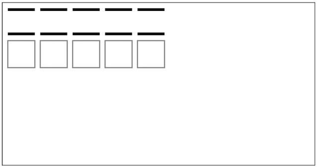

### Definindo estilos

| Nome Função | Descrição | Valores padrões |
| --- | --- | --- |
| fillStyle | Define o estilo utilizado para preencher as formas. | black |
| lineJoin | Define o estilo utilizado para uniões de linhas. | miter |
| lineWidth | Define a espessura das linhas. | 1.0 |
| strokeStyle | Define o estilo utilizado para linhas. | black |

### 3.1.2.2. Exemplo com Espessuras de Linhas

```
<!-- Arquivo index.html -->
<!DOCTYPE html>
<html lang="pt-br">
<head>
    <meta charset="UTF-8">
    <title>Canvas</title>
    <link rel="stylesheet" href="css/estilo.css">
</head>
<body>
  <canvas id="myCanvas" width="578" height="300"></canvas>
  <script src="js/js.js"></script>
</body>
</html>
```

```
/* Arquivo estilo.css */
canvas {
    border: thin solid black;
    margin: 5px;
}
```

```
/* Arquivo js.js */
window.onload = function () {
  let canvas = document.getElementById("myCanvas");
  let ctx = canvas.getContext("2d");

  /* Inserir seu código aqui */
  ctx.lineWidth = 4;
  ctx.strokeRect(10, 10, 50, 50);
  ctx.lineWidth = 6;
  ctx.strokeRect(70, 10, 50, 50);
  ctx.lineWidth = 8;
  ctx.strokeRect(130, 10, 50, 50);
  ctx.lineWidth = 10;
  ctx.strokeRect(190, 10, 50, 50);
};
```

**Saída:**

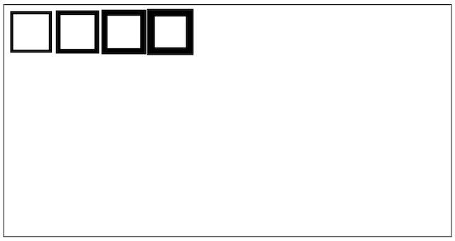

### 3.1.2.3. Exemplo com Junções de Linhas

```
<!-- Arquivo index.html -->
<!DOCTYPE html>
<html lang="pt-br">
<head>
    <meta charset="UTF-8">
    <title>Canvas</title>
    <link rel="stylesheet" href="css/estilo.css">
</head>
<body>
  <canvas id="myCanvas" width="578" height="300"></canvas>
  <script src="js/js.js"></script>
</body>
</html>
```

```
/* Arquivo estilo.css */
canvas {
    border: thin solid black;
    margin: 5px;
}
```

```
/* Arquivo js.js */
window.onload = function () {
  let canvas = document.getElementById("myCanvas");
  let ctx = canvas.getContext("2d");

  /* Inserir seu código aqui */
  ctx.lineWidth = 20;
  ctx.lineJoin = "round";
  ctx.strokeRect(20, 20, 100, 100);
  ctx.lineJoin = "bevel";
  ctx.strokeRect(160, 20, 100, 100);
  ctx.lineJoin = "miter";
  ctx.strokeRect(300, 20, 100, 100);
};
```

**Saída:**

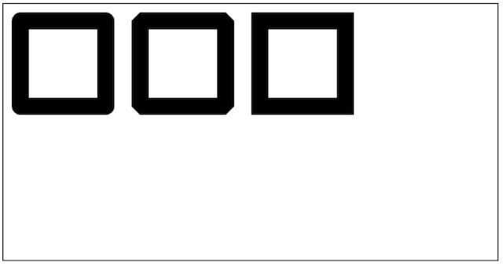

### 3.1.2.4. Exemplo com Preenchimento

```
<!-- Arquivo index.html -->
<!DOCTYPE html>
<html lang="pt-br">
<head>
    <meta charset="UTF-8">
    <title>Canvas</title>
    <link rel="stylesheet" href="css/estilo.css">
</head>
<body>
  <canvas id="myCanvas" width="578" height="300"></canvas>
  <script src="js/js.js"></script>
</body>
</html>
```

```
/* Arquivo estilo.css */
canvas {
    border: thin solid black;
    margin: 5px;
}
```

```
/* Arquivo js.js */
window.onload = function () {
  let canvas = document.getElementById("myCanvas");
  let ctx = canvas.getContext("2d");

  /* Inserir seu código aqui */
  let x = 10;
  let y = 50;
  let count = 5;
  ctx.lineWidth = 3;
  let interiorCores = ["black", "blue", "gray", "red", "green"];
  let linhasCores = ["rgb(0, 0, 0)", "rgb(100, 100, 100)", "rgb(0, 0, 255)", "rgb(255, 0, 0)", "rgb(0, 255, 0)"];

  for (let i = 0; i < count; i++) {
    ctx.fillStyle = interiorCores[i];
    ctx.strokeStyle = linhasCores[i];
    ctx.fillRect(i * (x + y) + x, x, y, y);
    ctx.strokeRect(i * (x + y) + x, (2 * x) + y, y, y);
};
```

**Saída:**

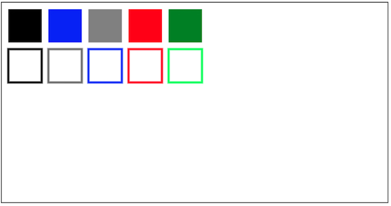

### Definindo Gradientes

| Nome Função | Descrição | Retorno |
| --- | --- | --- |
| createLinearGradient(x0, y0, x1, y1) | Cria um gradiente linear. | CanvasGradient |
| createRadialGradient(x0, y0, r0, x1, y1, r1) | Cria um gradiente radial. | CanvasGradient |
| addColorStop(position, cor) | Adiciona cores sólidas a linhas gradientes. | Não retorna nada. |

### 3.1.2.5. Exemplo com Gradientes Linear

```
<!-- Arquivo index.html -->
<!DOCTYPE html>
<html lang="pt-br">
<head>
    <meta charset="UTF-8">
    <title>Canvas</title>
    <link rel="stylesheet" href="css/estilo.css">
</head>
<body>
  <canvas id="myCanvas" width="578" height="300"></canvas>
  <script src="js/js.js"></script>
</body>
</html>
```

```
/* Arquivo estilo.css */
canvas {
    border: thin solid black;
    margin: 5px;
}
```

```
/* Arquivo js.js */
window.onload = function () {
  let canvas = document.getElementById("myCanvas");
  let ctx = canvas.getContext("2d");

  /* Inserir seu código aqui */
  let gradiente = ctx.createLinearGradient(0, 0, 500, 140);
  gradiente.addColorStop(0, "green");
  gradiente.addColorStop(0.3, "blue");
  gradiente.addColorStop(0.5, "white");
  gradiente.addColorStop(0.7, "orange");
  gradiente.addColorStop(1, "red");
  ctx.fillStyle = gradiente;
  ctx.fillRect(0, 0, 500, 140);
};
```

**Saída:**

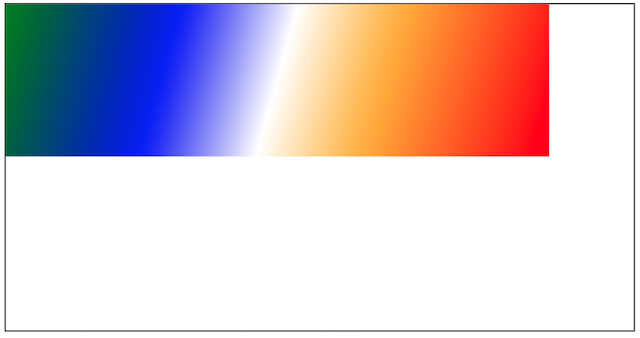

### 3.1.2.6. Exemplo com Gradientes Radial

```
<!-- Arquivo index.html -->
<!DOCTYPE html>
<html lang="pt-br">
<head>
    <meta charset="UTF-8">
    <title>Canvas</title>
    <link rel="stylesheet" href="css/estilo.css">
</head>
<body>
  <canvas id="myCanvas" width="578" height="300"></canvas>
  <script src="js/js.js"></script>
</body>
</html>
```

```
/* Arquivo estilo.css */
canvas {
    border: thin solid black;
    margin: 5px;
}
```

```
/* Arquivo js.js */
window.onload = function () {
  let canvas = document.getElementById("myCanvas");
  let ctx = canvas.getContext("2d");

  /* Inserir seu código aqui */
  let gradiente = ctx.createRadialGradient(250, 70, 20, 200, 60, 100);
  gradiente.addColorStop(0, "green");
  gradiente.addColorStop(0.3, "blue");
  gradiente.addColorStop(0.5, "white");
  gradiente.addColorStop(0.7, "orange");
  gradiente.addColorStop(1, "red");
  ctx.fillStyle = gradiente;
  ctx.fillRect(0, 0, 500, 140);
};
```

**Saída:**

[figure not shown]

### 3.1.2.7. Exemplo com Gradientes Linear e Radial

```
<!-- Arquivo index.html -->
<!DOCTYPE html>
<html lang="pt-br">
<head>
    <meta charset="UTF-8">
    <title>Canvas</title>
    <link rel="stylesheet" href="css/estilo.css">
</head>
<body>
  <canvas id="myCanvas" width="578" height="300"></canvas>
  <script src="js/js.js"></script>
</body>
</html>
```

```
/* Arquivo estilo.css */
canvas {
    border: thin solid black;
    margin: 5px;
}
```

```
/* Arquivo js.js */
window.onload = function () {
  let canvas = document.getElementById("myCanvas");
  let ctx = canvas.getContext("2d");

  /* Inserir seu código aqui */
  let gradiente = ctx.createLinearGradient(250, 70, 200, 160);
  gradiente.addColorStop(0, "green");
  gradiente.addColorStop(0.3, "blue");
  gradiente.addColorStop(0.5, "white");
  gradiente.addColorStop(0.7, "orange");
  gradiente.addColorStop(1, "red");
  ctx.fillStyle = gradiente;
  ctx.fillRect(150, 20, 75, 100);
  ctx.lineWidth = 8;
  ctx.strokeStyle = gradiente;
  ctx.strokeRect(250, 20, 75, 100);

  let gradienteR = ctx.createRadialGradient(250, 150, 20, 200, 100, 100);
  gradienteR.addColorStop(0, "green");
  gradienteR.addColorStop(0.3, "blue");
  gradienteR.addColorStop(0.5, "white");
  gradienteR.addColorStop(0.7, "orange");
  gradienteR.addColorStop(1, "red");
  ctx.fillStyle = gradienteR;
  ctx.fillRect(150, 150, 75, 100);
  ctx.lineWidth = 8;
  ctx.strokeStyle = gradienteR;
  ctx.strokeRect(250, 150, 75, 100);
};
```

**Saída:**

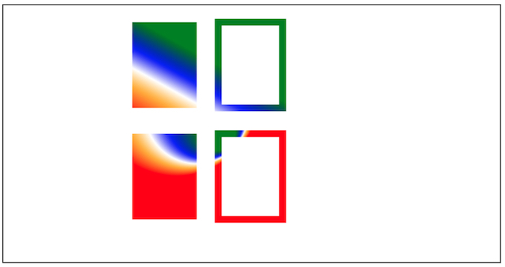

### Definindo Padrões

| Nome Função | Descrição |
| --- | --- |
| createPattern(imagem, repeticao) | Cria um padrão conforme a imagem passada. |
| repeat | A imagem será repetida na vertical e horizontal. |
| repeat-x | A imagem será repetida somente na horizontal. |
| repeat-y | A imagem será repetida somente na vertical. |
| no-repeat | A imagem será repetida não será repetida. |

### 3.1.2.8. Exemplo com Padrões

```
<!-- Arquivo index.html -->
<!DOCTYPE html>
<html lang="pt-br">
<head>
    <meta charset="UTF-8">
    <title>Canvas</title>
    <link rel="stylesheet" href="css/estilo.css">
</head>
<body>
  <canvas id="myCanvas" width="578" height="300"></canvas>
  <img src="bola.jpg" hidden id="bola">    <!-- Adicionado -->
  <script src="js/js.js"></script>
</body>
</html>
```

```
/* Arquivo estilo.css */
canvas {
    border: thin solid black;
    margin: 5px;
}
```

```
/* Arquivo js.js */
window.onload = function () {
  let canvas = document.getElementById("myCanvas");
  let ctx = canvas.getContext("2d");

  /* Inserir seu código aqui */
  let imagemElemento = document.getElementById("bola");
  let padrao = ctx.createPattern(imagemElemento, "repeat");  /* propriedade a ser modificada */
  ctx.fillStyle = padrao;
  ctx.fillRect(0, 0, 500, 140);
};
```

**Saída:**  
**let padrao = ctx.createPattern(imagemElemento, "repeat");**

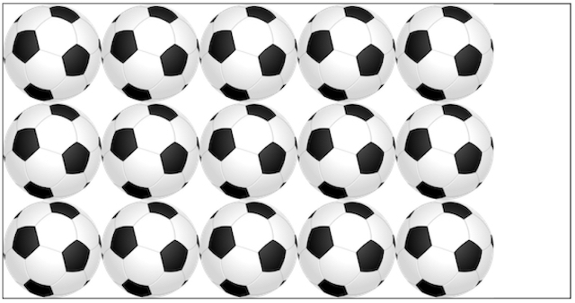

**let padrao = ctx.createPattern(imagemElemento, "repeat-x");**

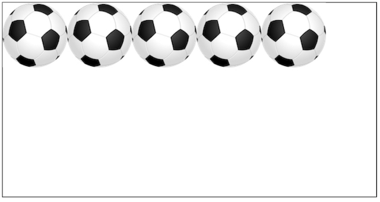

**let padrao = ctx.createPattern(imagemElemento, "repeat-y");**

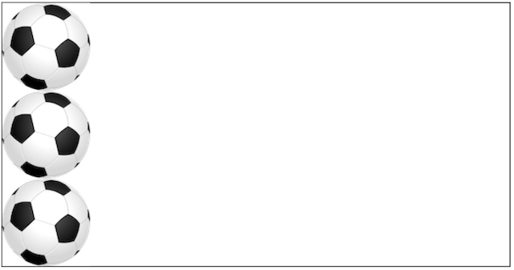

**let padrao = ctx.createPattern(imagemElemento, "no-repeat");**

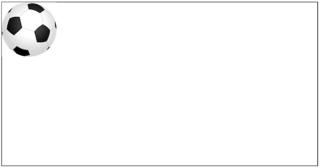

### 3.1.2.9. Exemplo com Padrões em formas geométricas

```
<!-- Arquivo index.html -->
<!DOCTYPE html>
<html lang="pt-br">
<head>
    <meta charset="UTF-8">
    <title>Canvas</title>
    <link rel="stylesheet" href="css/estilo.css">
</head>
<body>
  <canvas id="myCanvas" width="578" height="300"></canvas>
  <img src="bola.jpg" hidden id="bola">    <!-- Adicionado -->
  <script src="js/js.js"></script>
</body>
</html>
```

```
/* Arquivo estilo.css */
canvas {
    border: thin solid black;
    margin: 5px;
}
```

```
/* Arquivo js.js */
window.onload = function () {
  let canvas = document.getElementById("myCanvas");
  let ctx = canvas.getContext("2d");

  /* Inserir seu código aqui */
  let imagemElemento = document.getElementById("bola");
  let padrao = ctx.createPattern(imagemElemento, "repeat");
  ctx.fillStyle = padrao;
  ctx.fillRect(50, 16, 180, 165);
  ctx.lineWidth = 20;
  ctx.strokeStyle = padrao;
  ctx.strokeRect(350, 20, 175, 150);

};
```

**Saída:**

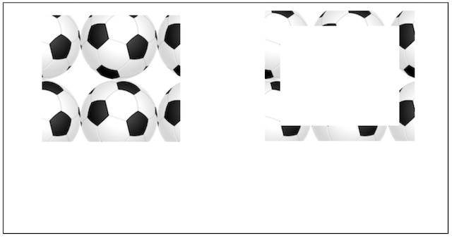

### Salvando e Restaurando Estados

| Nome Função | Descrição |
| --- | --- |
| save() | Salva os valores para as propriedades do estado do desenho e os organiza na pilha de estados. |
| restore() | Pega o primeiro conjunto de valores da pilha de estados e os utiliza para definir o estado de desenho. |

### 3.1.2.10. Exemplo com Save e Restore

```
<!-- Arquivo index.html -->
<!DOCTYPE html>
<html lang="pt-br">
<head>
    <meta charset="UTF-8">
    <title>Canvas</title>
    <link rel="stylesheet" href="css/estilo.css">
</head>
<body>
  <canvas id="myCanvas" width="578" height="300"></canvas>
  <div>                                 <!-- Adicionado -->
    <button>Save</button>               <!-- Adicionado -->
    <button>Restore</button>            <!-- Adicionado -->
  </div>                                <!-- Adicionado -->
  <script src="js/js.js"></script>
</body>
</html>
```

```
/* Arquivo estilo.css */
canvas {
    border: thin solid black;
    margin: 5px;
}
```

```
/* Arquivo js.js */
window.onload = function () {
  let canvas = document.getElementById("myCanvas");
  let ctx = canvas.getContext("2d");

  /* Inserir seu código aqui */
  let gradiente = ctx.createLinearGradient(500, 0, 500, 140);
  gradiente.addColorStop(0, "green");
  gradiente.addColorStop(0.3, "blue");
  gradiente.addColorStop(0.5, "white");
  gradiente.addColorStop(0.7, "orange");
  gradiente.addColorStop(1, "red");
  let interiorCores = ["black", gradiente, "blue", "gray", "red", "green", "grey"];
  let indexador = 0;
  ctx.fillStyle = interiorCores[indexador];
  draw();
  let botoes = document.getElementsByTagName("button");
  for (let i = 0; i < botoes.length; i++) {
    botoes[i].onclick = botaoPress;
  }

  function botaoPress(e) {
    switch (e.target.innerHTML) {
      case 'Save':
        ctx.save();
        indexador = (indexador + 1) % interiorCores.length;
        ctx.fillStyle = interiorCores[indexador];
        draw();
        break;

      case 'Restore':
        indexador = Math.max(0, indexador-1);
        ctx.restore();
        draw();
        break;
    }
  }

  function draw() {
    ctx.fillRect(0, 0, 500, 140);
  }
};
```

**Saída:**

- Ao pressionar o botão Save, a cor é modificada para outra contida no array interiorCores. E se for pressionado o Restore, ele exibe a cor anterior salva.

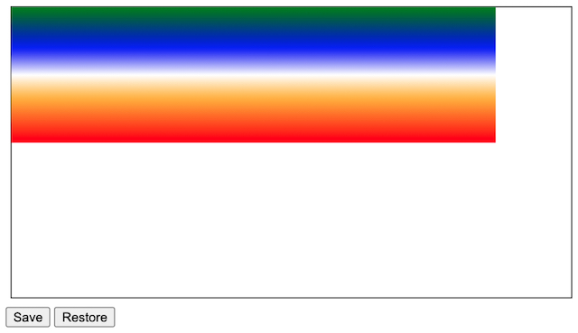

### DrawImage

[output not shown]

### 3.1.2.11. Exemplo com Desenhando Imagens a partir de Video

```
<!-- Arquivo index.html  - Modificado -->
<!DOCTYPE html>
<html lang="pt-br">
<head>
    <meta charset="UTF-8">
    <title>Canvas</title>
    <link rel="stylesheet" href="css/estilo.css">
</head>
<body>  <!-- Modificado! -->
    <video id="vid" src="timessquare.webm" controls preload="auto" width="360" height="240"></video>
    <div>
        <button id="pressme">Tirar Foto</button>
    </div>
    <canvas id="myCanvas" width="360" height="240"></canvas>

  <script src="js/js.js"></script>
</body>
</html>
```

```
/* Arquivo estilo.css   -   Modificado */
canvas {
  border: thin solid black;
}
/* elementos filhos diretos do elemento body receberão esta configuração */
body > * {
  float: left;
}
```

```
/* Arquivo js.js - Modificado */
  let canvas = document.getElementById("myCanvas");
  let ctx = canvas.getContext("2d");
  let imagemElemento = document.getElementById("vid");

  /* Inserir seu código aqui */
  document.getElementById("pressme").onclick = function (e) {
    ctx.drawImage(imagemElemento, 0, 0, 360, 238);
  }
};
```

**Saída:**

- Enquanto o video está sendo executado, ao pressionar o botão Foto, as imagens são capturadas e exibidas no canvas à direita.

[figure not shown]

### 3.1.2.12. Exemplo com Desenhando Imagens sobre um Video

```
<!-- Arquivo index.html  - Modificado -->
<!DOCTYPE html>
<html lang="pt-br">
<head>
  <meta charset="UTF-8">
  <title>Canvas</title>
  <link rel="stylesheet" href="css/estilo.css">
</head>
<body>  <!-- Modificado! -->
  <video id="vid" src="timessquare.webm" controls auto width="360" height="240"></video>
  <canvas id="myCanvas" width="360" height="240"></canvas>

<script src="js/js.js"></script>
</body>
</html>
```

```
/* Arquivo estilo.css   -   Modificado */
canvas {
  border: thin solid black;
}
/* elementos filhos diretos do elemento body receberão esta configuração */
body > * {
  float: left;
}
```

```
/* Arquivo js.js - Modificado */
  let canvas = document.getElementById("myCanvas");
  let ctx = canvas.getContext("2d");
  let imagemElemento = document.getElementById("vid");

  /* Inserir seu código aqui */
  let width = 100;
  let height = 10;
  ctx.lineWidth = 5;
  ctx.strokeStyle = "red";

  setInterval(function () {
    ctx.drawImage(imagemElemento, 0, 0, 360, 238);
    ctx.strokeRect(180 - (width/2), 120 - (height/2), width, height);
  }, 25);

  setInterval(function () {
    width = (width + 1) % 200;
    height = (height + 3) % 200;
  }, 100);
};
```

**Saída:**

- Enquanto o video está sendo executado à esquerda, o mesmo é reproduzido à direita porém, com um desenho de canvas sobre ele.

[figure not shown]

[figure not shown]

### 3.1.2.13. Exemplo Unindo as variações anteriores

```
<!-- Arquivo index.html  - Modificado -->
<!DOCTYPE html>
<html lang="pt-br">
<head>
  <meta charset="UTF-8">
  <title>Canvas</title>
  <link rel="stylesheet" href="css/estilo.css">
</head>
<body>  <!-- Modificado! -->
  <div>
    <video id="vid" src="timessquare.webm" controls autoplay width="360" height="240"></video>
  </div>
  <div>
    <canvas id="myCanvas1" width="360" height="240"></canvas>
    <button id="pressme">Foto</button>
    <canvas id="myCanvas2" width="360" height="240"></canvas>
  </div>
  <script src="js/js.js"></script>
</body>
</html>
```

```
/* Arquivo estilo.css   -   Modificado */
canvas {
  border: thin solid black;
}

body {
  display: flex;
  flex-direction: column;
  align-items: center;
}
```

```
/* Arquivo js.js - Modificado */
  let srcCanvas = document.getElementById("myCanvas1");
  let ctx1 = srcCanvas.getContext("2d");
  let ctx2 = document.getElementById("myCanvas2").getContext("2d");
  let imagemElemento = document.getElementById("vid");

  document.getElementById("pressme").onclick = takePicture;

  /* Inserir seu código aqui */
  let width = 100;
  let height = 10;
  ctx1.lineWidth = 5;
  ctx1.strokeStyle = "red";
  ctx2.lineWidth = 30;
  ctx2.strokeStyle = "black";

  setInterval(function () {
    ctx1.drawImage(imagemElemento, 0, 0, 360, 240);
    ctx1.strokeRect(180 - (width/2), 120 - (height/2), width, height);
  }, 25);

  setInterval(function () {
    width = (width + 1) % 200;
    height = (height + 3) % 200;
  }, 100);

  function takePicture() {
    ctx2.drawImage(srcCanvas, 0, 0, 360, 240);
    ctx2.strokeRect(0, 0, 360, 240);
  }
};
```

**Saída:**

- Enquanto o video está sendo executado à esquerda, o mesmo é reproduzido à abaixo, à esquerda com um desenho sobre, e à direita será exibido a foto ao pressionar o botão foto.

[figure not shown]

### Criando caminhos Path

| Nome Função | Descrição |
| --- | --- |
| beginPath() | Inicia um novo caminho. |
| closePath() | Fecha um caminho existente da primeira linha desenhada até a última. |
| fill() | Preenche as formas de subpaths. |
| isPointInPath(x, y) | Retorna verdadeiro se o ponto existe no caminho da forma desenhada. |
| lineTo(x, y) | Desenha uma subPath com as coordenadas indicadas. |
| moveTo(x, y) | Posiciona o cursor na coordenada especidicada. |
| rect(x, y, w, z) | Desenha um retângulo com início nos pontos (x, y), e com final nas coordenadas (w, z). |
| stroke() | Desenha a linha externa das formas. |

### Outras Propriedades

| Nome Função | Descrição |
| --- | --- |
| font = "bold 12px sans-serif" | Pode ser qualquer coisa que você colocaria na regra font do CSS. Incluindo font style, font variant, font weight, font size, line height, e font family. |
| textAlign = "right" | Controla o alinhamento do texto. É parecido (mas não idêntico) a regra text-align do CSS. Os possíveis valores são start, end, left, right, e center. |
| textBaseline = "bottom" | Controla onde o texto é desenhado relativo ao ponto de início. Os possíveis valores são top, hanging, middle, alphabetic, ideographic, ou bottom. |
| fillText(conteudo, posicao x, posicao y) | desenha o texto de fato. |

### 3.1.2.14. Exemplo Desenhando Linhas

```
<!-- Arquivo index.html  - Modificado -->
<!DOCTYPE html>
<html>
<head>
  <meta charset="utf-8">
  <title>Desenhando com Canvas</title>
  <link rel="stylesheet" href="css/estilo.css">
</head>
<body>
    <canvas id="myCanvas" width="500" height="600">Sem suporte a canvas</canvas>
    <script src="js/js1.js"></script>
</body>
</html>
```

```
/* Arquivo estilo.css   -   Modificado */
#myCanvas {
      border : 10px solid #555
    }
```

```
/* Arquivo js.js - Modificado */
    let canvas = document.getElementById("myCanvas1");
    let ctx = canvas.getContext("2d");

    //Desenhando linhas verticais
    for (let x = 0.5; x < 500; x += 10)
    {
      ctx.moveTo(x, 0);
      ctx.lineTo(x, 600);
    }
    //Desenhando linhas horizontais
    for (let y = 0.5; y < 600; y += 10)
    {
      ctx.moveTo(0, y);
      ctx.lineTo(600, y);
    }

    ctx.strokeStyle = "#eee";
    ctx.stroke();

    // Desenhando uma seta na Horizontal
    ctx.beginPath();
    ctx.moveTo(0, 40);
    ctx.lineTo(240, 40);
    ctx.moveTo(260, 40);
    ctx.lineTo(500, 40);
    ctx.moveTo(495, 35);
    ctx.lineTo(500, 40);
    ctx.lineTo(495, 45);

    // Desenhando uma seta na Vertical
    ctx.moveTo(60, 0);
    ctx.lineTo(60, 153);
    ctx.moveTo(60, 173);
    ctx.lineTo(60, 375);
    ctx.moveTo(65, 370);
    ctx.lineTo(60, 375);
    ctx.lineTo(55, 370);

    ctx.strokeStyle = "#000";
    ctx.stroke();


    //Desenhando x, y, e as coordenadas
    ctx.font = "bold 12px sans-serif";
    ctx.fillText("x", 248, 43);
    ctx.fillText("y", 58, 165);

    ctx.textBaseline = "top";
    ctx.fillText("( 0 , 0 )", 8, 5);

    ctx.textAlign = "right";
    ctx.textBaseline = "bottom";
    ctx.fillText("( 500 , 375 )", 492, 370);
};
```

**Saída:**

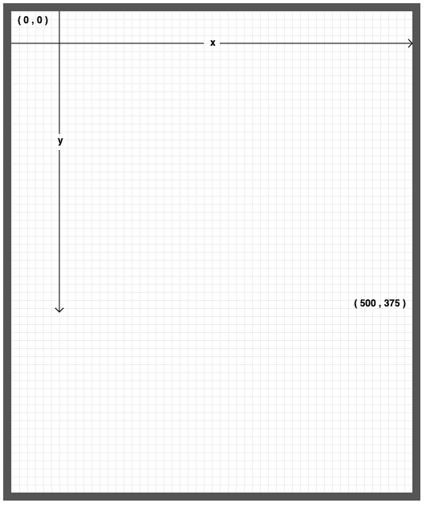

### 3.2. Animação com Javascript

- Para visualizar exemplos, consulte [Javascript.info](https://javascript.info/js-animation).

### 4. Usando XML com CSS

```
<!-- Arquivo index.xml -->

<?xml version="1.0"?>
<!-- XML demonstration -->

<?xml-stylesheet type="text/css" href="estilo.css"?>

<!DOCTYPE planet>
<planet>

<ocean>
<name>Arctic</name>
<area>13,000</area>
<depth>1,200</depth>
</ocean>

<ocean>
<name>Atlantic</name>
<area>87,000</area>
<depth>3,900</depth>
</ocean>

<ocean>
<name>Pacific</name>
<area>180,000</area>
<depth>4,000</depth>
</ocean>

<ocean>
<name>Indian</name>
<area>75,000</area>
<depth>3,900</depth>
</ocean>

<ocean>
<name>Southern</name>
<area>20,000</area>
<depth>4,500</depth>
</ocean>

</planet>
```

```
/* Arquivo estilo.css */
/* ** XML demonstration ** */

planet:before {
  display: block;
  width: 8em;
  font-weight: bold;
  font-size: 200%;
  content: "Oceans";
  margin: -.75em 0px .25em -.25em;
  padding: .1em .25em;
  background-color: #cdf;
  }

planet {
  display: block;
  margin: 2em 1em;
  border: 4px solid #cdf;
  padding: 0px 1em;
  background-color: white;
  }

ocean {
  display: block;
  margin-bottom: 1em;
  }

name {
  display: block;
  font-weight: bold;
  font-size: 150%;
  }

area {
  display: block;
  }

area:before {
  content: "Area: ";
  }

area:after {
  content: " million km\B2";
  }

depth {
  display: block;
  }

depth:before {
  content: "Mean depth: ";
  }

depth:after {
  content: " m";
  }
```

**Saída:**

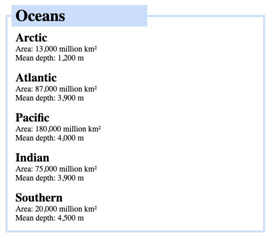

### Referências

- Esta aula foi elaborada a partir do conteúdo disponibilizado em cada um dos links indicados no próprio texto.
- Criando Formulários a partir do objeto [MDN Web Docs - FormData](https://developer.mozilla.org/en-US/docs/Web/API/FormData/Using_FormData_Objects).
- [Dive into HTML5](https://diveintohtml5.com.br).
- [HTML5 Canvas Tutorials](http://www.html5canvastutorials.com).
- [MDN Web Docs - Canvas Tutorial](https://developer.mozilla.org/pt-BR/docs/Web/Guide/HTML/Canvas_tutorial).
- [MDN Web Docs - CanvasRenderingContext2D](https://developer.mozilla.org/en-US/docs/Web/API/CanvasRenderingContext2D).
- [ADDISON, W.] - HTML5 Guidelines for Web Developers - Junho 2011
- [FREEMAN, A.] - The Definitive Guide to HTML5 - Editora Apress
- [SILVA, O. J.] - HTML 4.0 e XHTML 1.0 Domínio e Transição - Editora Erica.

### Perguntas

- Esclareça suas eventuais dúvidas durante as aulas.
- Ou pelo *E-mail*: paulagiancoli@ifsp.edu.br.
- Ou pelo *Fórum* do componente curricular.

*ADS - HTML5, CSS3, JS - 5o. módulo*.  
Modelo e formato elaborado por profa. Ana Paula Müller Giancoli - BSD 2-Clause License. - Julho.2020.